# Milestone Report 1

Sara Regina Ferreira de Faria

22/10/2018

## Download and Load Data of English

```r
download.file("https://d396qusza40orc.cloudfront.net/dsscapstone/dataset/Coursera-SwiftKey.zip", "data.zip")
```

```r
con <- file("final/en_US/en_US.twitter.txt", "r")
twitter <- readLines(con)
close(con)

con <- file("final/en_US/en_US.blogs.txt", "r")
blogs <- readLines(con)
close(con)

con <- file("final/en_US/en_US.news.txt", "r")
news <- readLines(con)
close(con)
```

## Summary about the data set

The data has four folders: one for each language. They are separated in german (de_DE), english (en_US), finish (fi_FI) and russian (ru_RU). In each file inside these folder there are many phrases in the selected language. Each phrase takes one line in the file and is wrapped in quotation marks. In this work we are going to deal only with English texts.

Number of lines in each data set:

```r
paste("twitter:", length(twitter))
```

```
## [1] "twitter: 2360148"
```

```r
paste("blogs:",length(blogs))
```

```
## [1] "blogs: 899288"
```

```r
paste("news",length(news))
```

```
## [1] "news 1010242"
```

The biggest text in each data set is:

```r
paste("twitter:", sort(nchar(twitter), decreasing = TRUE)[1])
```

```
## [1] "twitter: 140"
```

```r
paste("blogs:",sort(nchar(blogs), decreasing = TRUE)[1])
```

```
## [1] "blogs: 40833"
```

```r
paste("news",sort(nchar(news), decreasing = TRUE)[1])
```

```
## [1] "news 11384"
```

## Findings on the data set

Here we have clouds and the 10 more frequent words for the first 10000 entries in each data set:

# Load first 10000 entries of each dataset

```r
con <- file("final/en_US/en_US.twitter.txt", "r")
twitter <- readLines(con, 10000)
close(con)

con <- file("final/en_US/en_US.blogs.txt", "r")
blogs <- readLines(con, 10000)
close(con)

con <- file("final/en_US/en_US.news.txt", "r")
news <- readLines(con, 10000)
close(con)
```

# Twitter

```r
library(tm)
download.file("https://www.cs.cmu.edu/~biglou/resources/bad-words.txt", "profane");
profane <- read.table("profane")

toSpace <- content_transformer(function (x , pattern ) gsub(pattern, " ", x))

twitter <- Corpus(VectorSource(twitter), readerControl = list(language = "en"))
twitter <- tm_map(twitter, removePunctuation)
twitter <- tm_map(twitter, content_transformer(tolower))
twitter <- tm_map(twitter, removeWords, profane$V1)
twitter <- tm_map(twitter, toSpace, "/")
twitter <- tm_map(twitter, toSpace, "@")
twitter <- tm_map(twitter, toSpace, "\\|")
twitter <- tm_map(twitter, removeNumbers)
twitter <- tm_map(twitter, removeWords, stopwords("english"))
twitter <- tm_map(twitter, stripWhitespace)
```

```r
library(wordcloud)
library(tm)
gc()
```

```
##           used (Mb) gc trigger  (Mb) max used  (Mb)
## Ncells  581843 31.1    5539589 295.9  5514818 294.6
## Vcells 5892299 45.0   92519671 705.9 99558572 759.6
```

```r
twitter <- Corpus(VectorSource(twitter), readerControl = list(language = "en"))
dtmTwitter <- TermDocumentMatrix(twitter)
mTwitter <- as.matrix(dtmTwitter)
vTwitter <- sort(rowSums(mTwitter),decreasing=TRUE)
dTwitter <- data.frame(word = names(vTwitter),freq=vTwitter)
```

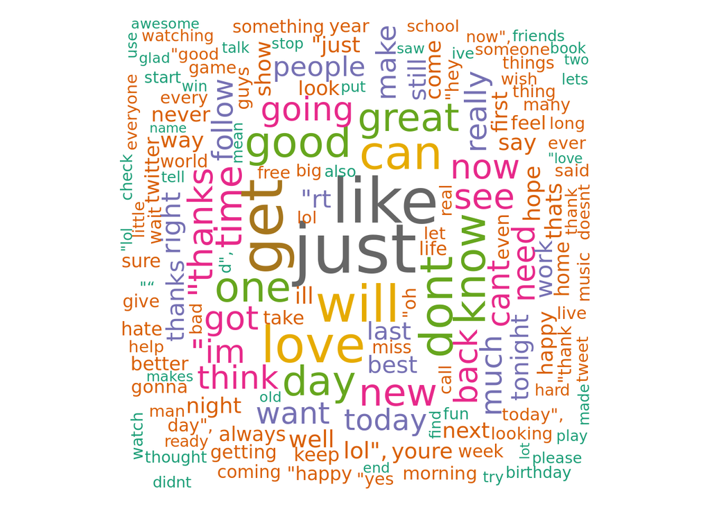

```r
set.seed(1)
wordcloud(words = dTwitter$word, freq = dTwitter$freq, min.freq = 1,
          max.words=200, random.order=FALSE, rot.per=0.35,
          colors=brewer.pal(8, "Dark2"))
```

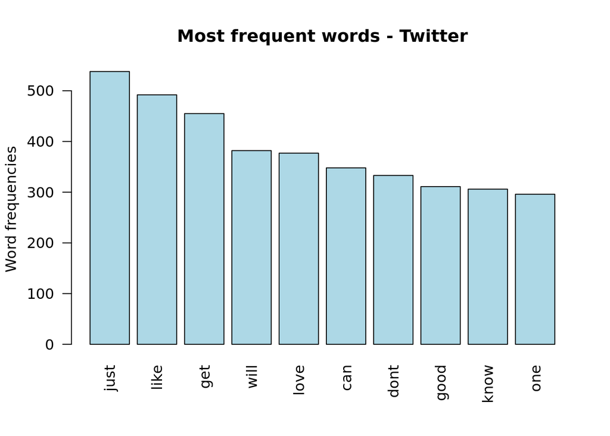

```r
barplot(dTwitter[1:10,]$freq, las = 2, names.arg = dTwitter[1:10,]$word,
        col ="lightblue", main ="Most frequent words - Twitter",
        ylab = "Word frequencies")
```

# Blogs

```r
blogs <- Corpus(VectorSource(blogs), readerControl = list(language = "en"))
blogs <- tm_map(blogs, removePunctuation)
blogs <- tm_map(blogs, content_transformer(tolower))
blogs <- tm_map(blogs, removeWords, profane$V1)
blogs <- tm_map(blogs, toSpace, "/")
blogs <- tm_map(blogs, toSpace, "@")
blogs <- tm_map(blogs, toSpace, "\\|")
blogs <- tm_map(blogs, removeNumbers)
blogs <- tm_map(blogs, removeWords, stopwords("english"))
blogs <- tm_map(blogs, stripWhitespace)
```

```r
gc()
```

```
##           used (Mb) gc trigger  (Mb) max used  (Mb)
## Ncells  622213 33.3    4431671 236.7  5539589 295.9
## Vcells 6042690 46.2   74015736 564.7 99558572 759.6
```

```r
blogs <- Corpus(VectorSource(blogs), readerControl = list(language = "en"))
dtmBlogs <- TermDocumentMatrix(blogs)
mBlogs <- as.matrix(dtmBlogs)
vBlogs <- sort(rowSums(mBlogs),decreasing=TRUE)
dBlogs <- data.frame(word = names(vBlogs),freq=vBlogs)
```

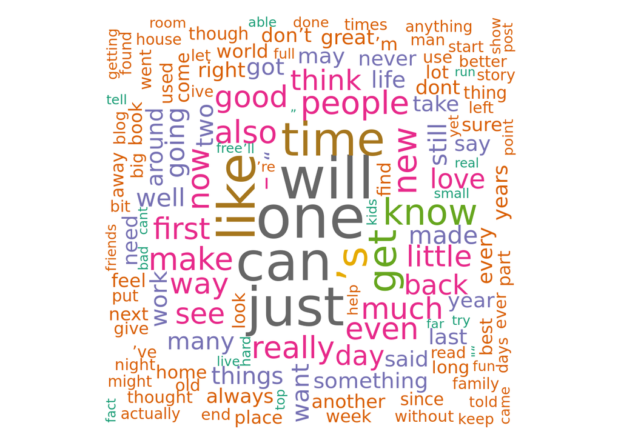

```r
set.seed(1)
wordcloud(words = dBlogs$word, freq = dBlogs$freq, min.freq = 1,
          max.words=200, random.order=FALSE, rot.per=0.35,
          colors=brewer.pal(8, "Dark2"))
```

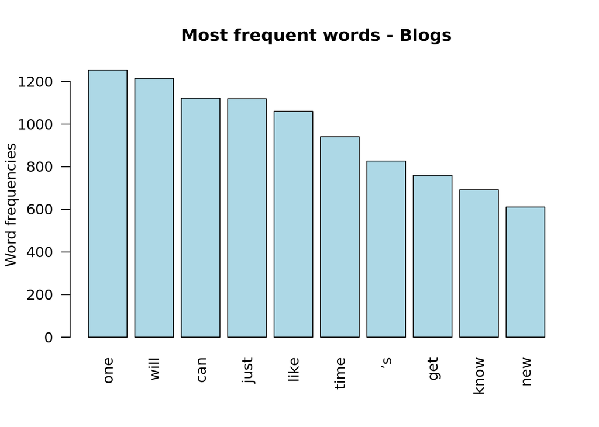

```r
barplot(dBlogs[1:10,]$freq, las = 2, names.arg = dBlogs[1:10,]$word,
        col ="lightblue", main ="Most frequent words - Blogs",
        ylab = "Word frequencies")
```

# News

```r
news <- Corpus(VectorSource(news), readerControl = list(language = "en"))
news <- tm_map(news, removePunctuation)
news <- tm_map(news, content_transformer(tolower))
news <- tm_map(news, removeWords, profane$V1)
news <- tm_map(news, toSpace, "/")
news <- tm_map(news, toSpace, "@")
news <- tm_map(news, toSpace, "\\|")
news <- tm_map(news, removeNumbers)
news <- tm_map(news, removeWords, stopwords("english"))
news <- tm_map(news, stripWhitespace)
```

```r
gc()
```

```
##           used (Mb) gc trigger  (Mb) max used  (Mb)
## Ncells  640139 34.2    3545336 189.4  5539589 295.9
## Vcells 6387902 48.8   59212588 451.8 99558572 759.6
```

```r
news <- Corpus(VectorSource(news), readerControl = list(language = "en"))
dtmNews <- TermDocumentMatrix(news)
mNews <- as.matrix(dtmNews)
vNews <- sort(rowSums(mNews),decreasing=TRUE)
dNews <- data.frame(word = names(vNews),freq=vNews)
```

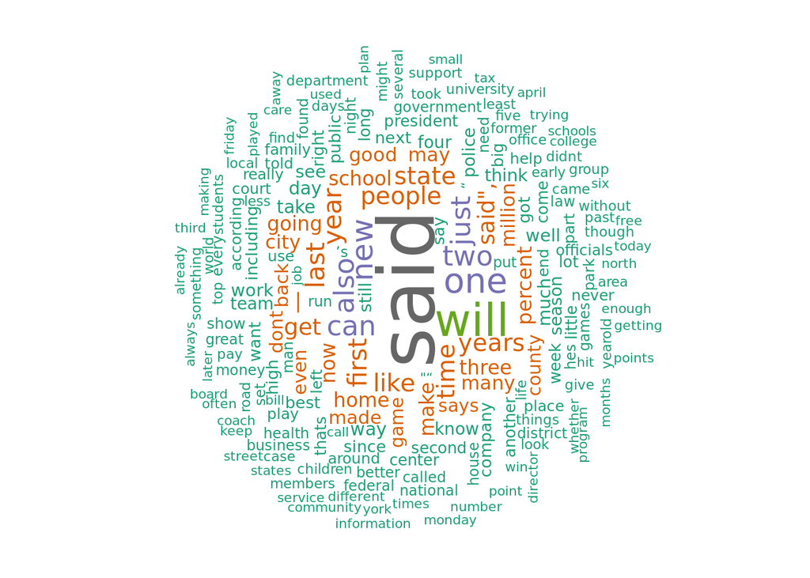

```r
set.seed(1)
wordcloud(words = dNews$word, freq = dNews$freq, min.freq = 1,
          max.words=200, random.order=FALSE, rot.per=0.35,
          colors=brewer.pal(8, "Dark2"))
```

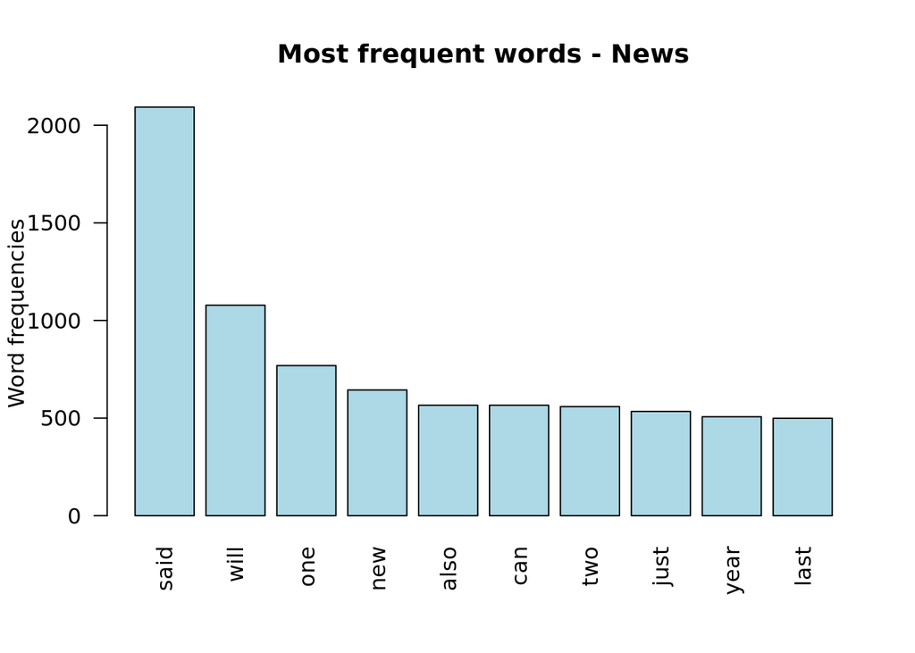

```r
barplot(dNews[1:10,]$freq, las = 2, names.arg = dNews[1:10,]$word,
        col ="lightblue", main ="Most frequent words - News",
        ylab = "Word frequencies")
```

## Plans for prediction algorithm and Shiny App

The basic prediction can be made using n-grams, i.e. combination of words included in the data set. In this way we can predict the next word as the most frequent word after the typed combination of words.

The Shiny App will be simple: just a box to type a sentence and as the person writes the words, the model suggests the next one based in everything that was typed until then.